# PSC 794 (Spring 2022): Missing Data R Code

Baobao Zhang

# Prepare: load packages and the dataset

We will be using the attitude dataset as our example.

## Description of the dataset

From a survey of the clerical employees of a large financial organization, the data are aggregated from the questionnaires of the approximately 35 employees for each of 30 (randomly selected) departments. The numbers give the *percent proportion of favourable responses* to seven questions in each department.

https://www.rdocumentation.org/packages/datasets/versions/3.6.2/topics/attitude

The main outcome variable is `rating` (the overall favourable rating). Each unit is a department.

```r
# Load the required packages
require(stats)
require(graphics)
require(Hmisc)
require(ggplot2)
# Set seed for the randomizations that we will do
set.seed(8130)
```

```r
# Load the attitude dataset
data("attitude")

# Get the summary statistics of the main outcome variable rating
mean(attitude$rating)
```

```
## [1] 64.63333
```

```r
# The expected value for rating is 64.63
```

# Missing completely at random

```r
# Let's make some of the observations missing completely at random with 20% probability
mcar_units <- sample(x = c(TRUE, FALSE),
                     size = nrow(attitude),
                     replace = TRUE,
                     prob = c(0.8, 0.2))

# Make a new variable where if mcar_units is TRUE, we make the rating missing
attitude$rating_mcar <- ifelse(mcar_units, attitude$rating, -99)

# Look the summary of outcomes
table(attitude$rating_mcar == -99)
```

```
##
## FALSE  TRUE
##    28     2
```

```r
# Look at the mean without the missings
mean(attitude$rating_mcar[!attitude$rating_mcar == -99])
```

```
## [1] 64.57143
```

Because our units are missing completely at random, missingness is independent of the outcome. We can *mean-impute* by plugging-in the expected value of the non-missing outcome for the missing units.

```r
# Plug in the expected value (i.e., mean) of the non-missing outcomes
attitude$rating_mcar[attitude$rating_mcar == -99] <-
  mean(attitude$rating_mcar[attitude$rating_mcar != -99])

# Notice that the expected value of the rating is the same as what we got in the previous chunk
# We can either mean-impute or just ignore the NAs
# Mean-impute might be more helpful when you're worried about list-wise deletion
mean(attitude$rating_mcar)
```

```
## [1] 64.57143
```

```r
# Let's remove the rating_mcar variable
attitude$rating_mcar <- NULL
```

# Missing at random

Again, we are generating missing data. But this time, we are generating them *missing at random* considition on the other variables in the dataset.

First, we generate a propensity score using a linear probability model.

```r
# The propensity score was generated using a linear probability model (think OLS).
attitude$propensity_score <- 0.75+
  0.1*(attitude$complaints/100) +
  -0.2*(attitude$privileges/100) +
  0.2*(attitude$learning/100) +
  -0.4*(attitude$raises/100) +
  0.2*(attitude$critical/100) +
  -0.1*(attitude$advance/100)

# Look at the summary of the propensity score
summary(attitude$propensity_score)
```

```
##    Min. 1st Qu.  Median    Mean 3rd Qu.    Max.
##  0.5490  0.6445  0.6710  0.6711  0.6860  0.7340
```

```r
# A function to generate whether each unit is missing or not
# FALSE = missing
# TRUE = not missing
generate_mar <- function(unit_number) {
  sample(x = c(TRUE, FALSE), size = 1, replace = TRUE,
         # Probability of being observed is the propensity score
         prob = c(attitude$propensity_score[unit_number],
         # Probability of missing is 1 minus the propensity score
                  1-attitude$propensity_score[unit_number]))
}

# Run the function for each unit
# lapply will return a list
# we must apply the unlist function to convert it to a vector
mar <- unlist(lapply(1:nrow(attitude), generate_mar))
attitude$mar <- mar

# Look at the distribution of missing
table(mar)
```

```
## mar
## FALSE  TRUE
##     9    21
```

```r
# Make a new variable with the missing data
attitude$rating_mar <- ifelse(mar == FALSE, -99, attitude$rating)

# What happens if we just ignore the NAs
mean(attitude$rating_mar[attitude$rating_mar != -99])
```

```
## [1] 61.47619
```

Now that we have generated our missing data, we will try to estimate the expected outcome using several different methods.

## Manski bounds

This method tries to bound the expected outcome given what we know about the range of possible values the outcome can take. Since the outcome is a percentage, the smallest possible value is 0 and the biggest possible value is 100.

- To estimate the lower bound, we plug in the smallest possible value (0) for the missing units.
- To estimate the upper bound, we plug in the biggest possible value (100) for the missing units.

```r
# Lower bound
attitude$rating_mar_lower <- ifelse(attitude$rating_mar == -99,
                                    # if the unit is missing, plug in the lowest possible value
                                    0,
                                    attitude$rating_mar)
# Get the expected value for the lower bound
mean(attitude$rating_mar_lower)
```

```
## [1] 43.03333
```

```r
# Upper bound
attitude$rating_mar_upper <- ifelse(attitude$rating_mar == -99,
                                    # if the unit is missing, plug in the lowest possible value
                                    100,
                                    attitude$rating_mar)
# Get the expected value for the upper bound
mean(attitude$rating_mar_upper)
```

```
## [1] 73.03333
```

The Manski bounds for the expected value of rating is [43.0333333, 73.0333333].

## Post-stratification

Post-stratification will be a bit tricky because all the covariates are numerical values. In this example, I am going to create some strata based on an aggregate score that’s the sum of the covariates.

```r
# Make an aggregate score that sums up the covariates
aggregate_covariate_score <- rowSums(attitude[,c("complaints", "privileges", "learning",
            "raises", "critical", "advance")])

# Cut the aggregate score into quantiles to generate the strata
quantiles <- quantile(aggregate_covariate_score, probs = c(0.25, 0.50, 0.75))
attitude$strata <- Hmisc::cut2(aggregate_covariate_score, cuts = as.numeric(quantiles))

# Write a function where we can calculate the strata mean and the probability of being in that strata
strata_function <- function(strata) {
  # Mean of the strata
  strata_mean <- mean(attitude$rating_mar[attitude$strata == strata &
                                            attitude$rating_mar != -99])
  # Probability of being in the strata
  strata_prob <- sum(attitude$strata == strata)/nrow(attitude)
  # Output
  return(data.frame(strata_mean, strata_prob))
}

# Apply the function to each of the strata
strata_outcomes <- lapply(X = levels(attitude$strata), FUN = strata_function)
# Make into a data frame
strata_outcomes <- do.call(rbind, strata_outcomes)

# To estimate the expected value
# We sum up the products of the strata mean and the probability of being in that strata
sum(strata_outcomes$strata_mean * strata_outcomes$strata_prob)
```

```
## [1] 63.32333
```

The estimate using post-stratification is 63.3233333.

## Regression

Next we use OLS regression to impute the missing outcomes.

```r
# Run the regression
lm_output <- lm(formula = rating ~ complaints + privileges + learning +
     raises + critical + advance, data = attitude)

# Get the vector of predicted outlines based on the regression model above
lm_predicted_rating <- predict(lm_output, newdata = attitude)

# We can put the imputed values into the missing units
attitude$rating_mar_ols_impute <- ifelse(attitude$rating_mar == -99,
                                         lm_predicted_rating,
                                         attitude$rating_mar)
# Get the mean
mean(attitude$rating_mar_ols_impute)
```

```
## [1] 64.60919
```

The estimate using imputation through regression is 64.6091914.

## Inverse probability weighting

We will use inverse probability weighting (IPW) to estimate the expected value.

First, we will use the propensity score (which we magically know because we generated it!).

```r
# Make the IPW weights from the actual propensity scores
attitude$IPW_weights <- 1/attitude$propensity_score

# Get the IPW estimate
mean(attitude$rating_mar * attitude$mar * attitude$IPW_weights)
```

```
## [1] 64.60184
```

```r
ipw_estimate <- mean(attitude$rating_mar * attitude$mar * attitude$IPW_weights)
```

The expected value estimated from the IPW estimator (using the actual propensity score) is 64.6018438.

Next, we will do what researchers do in the real-world where they don’t magically know the propensity score. We would need to estimate the propensity score using logistic regression. Notice that we did not get great results here because the propensity scores were not generated using a logistic function.

```r
# Use logistic regression to estimate the propensity score
logit_output <- glm(formula = mar ~ complaints + privileges + learning +
     raises + critical + advance, data = attitude, family = "binomial")
# The fitted values are our estimated propensity scores
attitude$estimated_IPW_weights <- 1/logit_output$fitted.values

# Get the IPW estimate
mean(attitude$rating_mar * attitude$mar * attitude$estimated_IPW_weights)
```

```
## [1] 80.02091
```

The expected value estimated from the IPW estimator (using our estimated propensity scores) is 80.0209125.

## Stabilized inverse probability weighting

The IPW estimator has high variability (that is, its standard error is large) with small samples. So we want to stablize the IPW weights.

```r
# Look at the distribution of the IPW weights before we stabilize them
summary(attitude$IPW_weights)
```

```
##    Min. 1st Qu.  Median    Mean 3rd Qu.    Max.
##   1.362   1.458   1.490   1.495   1.552   1.821
```

```r
# With the weights, our sample is much bigger than 30!
sum(attitude$IPW_weights)
```

```
## [1] 44.86119
```

```r
# Create the stabilized weights
attitude$IPW_weights_s <- (attitude$IPW_weights/sum(attitude$IPW_weights))*
  nrow(attitude)
summary(attitude$IPW_weights_s)
```

```
##    Min. 1st Qu.  Median    Mean 3rd Qu.    Max.
##  0.9111  0.9748  0.9966  1.0000  1.0376  1.2181
```

```r
# You can take the weighted mean of the non-missing variables
wtd.mean(attitude$rating_mar[attitude$rating_mar != -99],
         weights = attitude$IPW_weights_s[attitude$rating_mar != -99])
```

```
## [1] 61.60135
```

```r
# Get the stabilized IPW estimate
mean(attitude$rating_mar * attitude$mar * attitude$IPW_weights)/
  mean(attitude$mar * attitude$IPW_weights)
```

```
## [1] 61.60135
```

The stabilized IPW estimate is 61.6013495.

# Doubly robust estimator

We can combine the regression estimator with the IPW estimator to make our estimates less biased. The first part of the estimator is the reression estimator and the second part of the estimator is an IPW estimator correcting for any unusual deviations between the actual data and the regression estimate. Let’s use it with our estimated propensity score because we knew that result was not very good.

```r
# Get the predicted outcome from our OLS model
lm_predict_rating <- predict(lm_output, newdata = attitude)

# Standard regression estimator
mean(lm_predict_rating) +
# IPW estimator correcting for any unusual deviations between the actual data and the regression estimate
  mean((attitude$mar)*(attitude$rating_mar - lm_predict_rating)*
         attitude$estimated_IPW_weights)
```

```
## [1] 62.58125
```

```r
doubly_estimate <- mean(lm_predict_rating) +
  mean((attitude$mar)*(attitude$rating_mar - lm_predict_rating)*
         attitude$estimated_IPW_weights)
```

The estimate from the doubly robust estimator is 62.581254.

# The bootstrap

It’s great that we are able to estimate the mean of our outcome `rating`. What about the standard error of the mean? Or the 95% confidence interval of the mean?

We can use a method called the bootstrap. Bootstrapping is a resampling procedure that uses data from one sample to generate a sampling distribution by repeatedly taking random samples from the known sample, with replacement.

Steps to create a bootstrap sample:

1. Replace the population with the sample.
2. Sample with replacement *M* times. *M* should be large, say 1000 times. (You probably need to run it 5000 or 10000 times when you’re doing research.)
3. Compute sample estimate each time.
4. Obtain the approximate distribution of the sample estimate.

Let’s try it for our IPW estimate using the known propensity score.

```r
bootstrap_function <- function() {
  # Create a smaller dataset where we can sample from
  min_df <- attitude[,c("rating_mar", "mar", "IPW_weights")]
  # Sample with replacement
  min_df_sim <- min_df[sample(x = 1:nrow(min_df),
                              size = nrow(min_df), # We have the sample the same size as our original sample
                              replace = TRUE),]
  # Get the IPW estimate for this simulated "sampled" dataset we just created
  return(mean(min_df_sim$rating_mar * min_df_sim$mar * min_df_sim$IPW_weights))
}

# Run the bootstrap function M times
M = 2000 # you can set it to something smaller if your computer is not that powerful
bootstrap_estimates <- replicate(n = M, bootstrap_function())

# You can get out the standard error by taking the standard deviation.
sd(bootstrap_estimates)
```

```
## [1] 8.34748
```

```r
# You can get the 95% confidence interval by taking the 2.5 and 97.5% percentile
quantile(bootstrap_estimates, probs = c(0.025, 0.975))
```

```
##    2.5%   97.5%
## 47.5384 80.4933
```

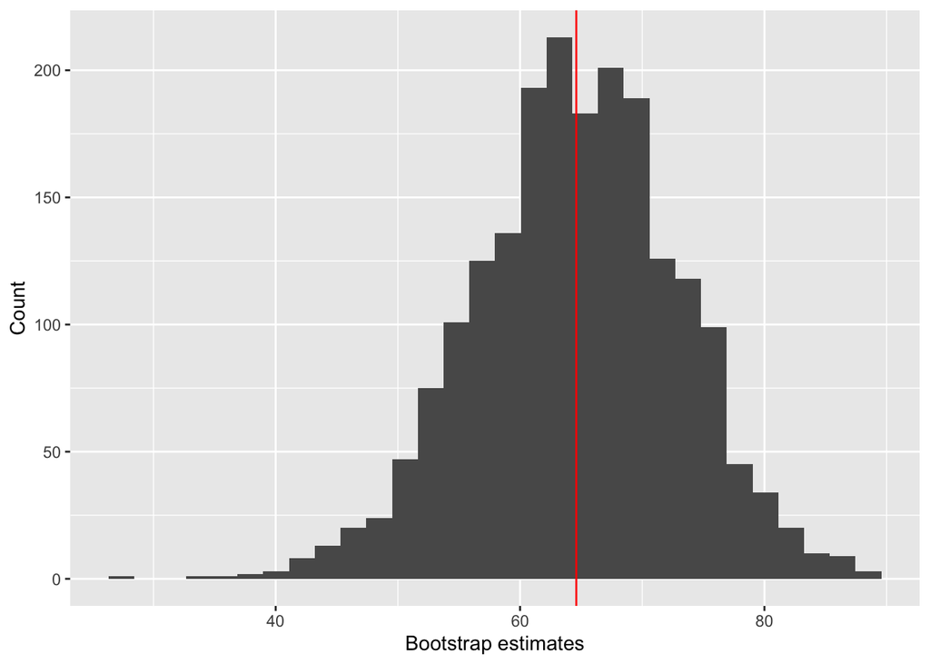

```r
# Let's make a plot

ggplot() +
  geom_histogram(aes(x = bootstrap_estimates)) +
  geom_vline(xintercept = ipw_estimate, color = "red") +
  xlab("Bootstrap estimates") + ylab("Count")
```